# Humidy_level_model

Before imputing NAs using mode and median, we need to split the train and test data to avoid data leakage.

```r
# before imputing, we will split the data into train and test data
set.seed(32678940) #Student ID as random seed
train_idxs = sample(1:nrow(WAUS), 0.75*nrow(WAUS))
WAUS_train = WAUS[train_idxs,]
WAUS_test = WAUS[-train_idxs,]
```

```r
# ensure that no years and locations are null
# remove rows wuth unknown Year
WAUS_train <- WAUS_train[!is.na(WAUS_train$Year),]

# we also removes rows with target value = NA
WAUS_train <- WAUS_train[!is.na(WAUS_train$MHT),]
```

Now, since we compute median for numerical variables and mode for categorical variables, we need to separate the train dataframe in to numerical and categorical dataframe.

```r
col_data_types = sapply(WAUS_train, class)
# separe the numerical and categorical columns
numerical_cols = WAUS_train[col_data_types=="integer" | col_data_types=="numeric"]
categorical_cols = WAUS_train[col_data_types=="character" | col_data_types=="factor"]
```

This function is used to compute the median of each numerical column.

```r
# group by locations and year
# calculate median value for each missing value (e.g. for sunshine)
# impute corresponding fields by that value
overall_medians = sapply(numerical_cols, median, na.rm = T)

get_median_without_na <- function(x, col_name){
  # input x shou;d be a column vector

  # if there are only NA values in this column, just return the overall mode
  if (length(x[!is.na(x)]) == 0){
    return(overall_medians[col_name])
  }
  # if there is at least one non-NA value return the mode among them
  return(median(x, na.rm = TRUE))
}


medians <- numerical_cols %>% group_by(Location, Year) %>% summarize(across(everything(), get_median_without_na, col_name = cur_column()))
```

This function is used to compute the mode for each categorical column.

```r
# for categorical columns, we find the mode
get_mode <- function(x) {
  # input x shou;d be a column vector
  x <- x[!is.na(x)]
  tab <- table(x)
  mode <- names(tab)[which.max(tab)]
  return(mode)
}

overall_modes <- sapply(categorical_cols, get_mode)


get_mode_without_na <- function(x, col_name){
  # input x shou;d be a column vector

  # if there are only NA values in this column, just return the overall mode
  if (length(x[!is.na(x)]) == 0){
    return(overall_modes[col_name])
  }
  # if there is at least one non-NA value return the mode among them
  return(get_mode(x))
}


modes <- cbind(WAUS_train[c("Location", "Year")], categorical_cols) %>% group_by(Location, Year) %>% summarize(across(everything(), get_mode_without_na, col_name = cur_column()))
```

Now, we join the medians and modes dataframes so that we have one dataframe representing a central value for every column in the dataset.

```r
central_values <- left_join(medians, modes, by=c("Location"="Location", "Year" = "Year"))
```

```r
central_values
```

| Location | Year | MinTemp | MaxTemp | Rainfall | Evaporation | Sunshine | WindGustSpeed | WindSpeed9am | WindSpeed3pm | Pressure9am | Pressure3pm | Cloud9am | Cloud3pm | Temp9am | Temp3pm | RISK_MM | WindGustDir | WindDir9am | WindDir3pm | RainToday | MHT |
| --- | --- | --- | --- | --- | --- | --- | --- | --- | --- | --- | --- | --- | --- | --- | --- | --- | --- | --- | --- | --- | --- |
| 2 | 2008 | 14.00 | 19.60 | 0.0 | 8.00 | 12.20 | 39.0 | 7.0 | 22.0 | 1016.50 | 1013.80 | 2.0 | 4.0 | 17.50 | 19.00 | 0.0 | SE | SE | ESE | No | 1 |
| 2 | 2009 | 12.45 | 18.30 | 0.2 | 4.30 | 5.60 | 39.0 | 9.0 | 23.0 | 1016.50 | 1014.05 | 7.5 | 7.0 | 16.10 | 17.20 | 1.2 | SE | E | ESE | No | 1 |
| 2 | 2010 | 13.55 | 18.55 | 0.4 | 3.40 | 6.15 | 39.0 | 12.0 | 30.0 | 1023.40 | 1021.75 | 7.0 | 5.5 | 16.90 | 17.40 | 0.0 | SE | ESE | E | No | 0 |
| 2 | 2011 | 11.50 | 18.00 | 0.8 | 4.20 | 5.20 | 39.0 | 15.0 | 13.0 | 1018.50 | 1018.80 | 7.0 | 6.0 | 14.60 | 17.50 | 0.8 | SE | NW | ESE | No | 1 |
| 2 | 2012 | 10.60 | 19.25 | 0.0 | 2.80 | 4.60 | 39.0 | 9.0 | 24.0 | 1015.55 | 1011.90 | 6.0 | 4.5 | 15.10 | 18.40 | 0.0 | SE | NW | E | No | 0 |
| 2 | 2013 | 14.40 | 21.50 | 0.0 | 4.00 | 6.00 | 39.0 | 17.0 | 12.0 | 1016.80 | 1015.85 | 7.0 | 6.0 | 18.70 | 19.65 | 0.0 | SE | S | S | No | 0 |
| 2 | 2014 | 12.40 | 19.00 | 1.4 | 3.60 | 5.20 | 39.0 | 7.0 | 14.0 | 1020.70 | 1016.60 | 6.0 | 6.0 | 15.50 | 17.80 | 1.6 | SE | S | NNW | Yes | 1 |
| 2 | 2015 | 11.80 | 19.40 | 0.0 | 4.40 | 5.60 | 39.0 | 15.0 | 9.0 | 1024.10 | 1020.50 | 5.0 | 6.0 | 17.70 | 18.50 | 0.0 | SE | SW | W | No | 1 |
| 5 | 2009 | 10.20 | 21.90 | 0.0 | 5.00 | 5.00 | 41.0 | 9.0 | 20.0 | 1019.50 | 1015.80 | 5.0 | 5.0 | 17.30 | 21.50 | 0.0 | WNW | SW | NNE | No | 1 |
| 5 | 2010 | 11.90 | 24.00 | 0.2 | 5.00 | 5.00 | 42.5 | 11.0 | 22.0 | 1018.50 | 1017.90 | 5.0 | 5.0 | 17.20 | 20.80 | 0.1 | N | NNE | E | No | 1 |

[output cut: 99 more lines]

Below function is used to ensure that if there is a pair of locatoin and year values that weren’t seen in the train data, they are imputed as follow: 1) some year of the same location. 2) if 1) is not possible, some location of the same year. 3) if 2) is not posdsible, just pick a random pair of year and location in the central_values dataframe.

```r
get_a_random_year_and_location <- function(central_values){
  random_row = central_values[sample(1:nrow(central_values), 1),]
  location = random_row["Location"]
  year = random_row["Year"]

  return(c(year, location))
}

get_year_location_pair <- function(year, location, central_values) {
  # check if both location and year are missing
  if (is.na(location) & is.na(year)) {
    # pick a row randomly
    return(get_a_random_year_and_location(central_values))
  }

  # check if the pair exists in the central_values dataframe
  if (!is.na(location) & !is.na(year) & nrow(central_values[central_values$Location == location & central_values$Year == year, ]) > 0) {
    return(c(year, location))
  }

  # check if rows with the same location exist
  if (!is.na(location)) {
    df_same_loc <- central_values[central_values$Location == location, ]
    if (nrow(df_same_loc) > 0) {
      year <- df_same_loc[sample(1:nrow(df_same_loc), 1), "Year"]
      return(c(year, location))
    }
  }

  # check if rows with the same year exist
  if (!is.na(year)) {
    df_same_year <- central_values[central_values$Year == year, ]
    if (nrow(df_same_year) > 0) {
      location <- df_same_year[sample(1:nrow(df_same_year), 1), "Location"]
      return(c(year, location))
    }
  }

  # pick a row randomly if no matching location or year is found
  return(get_a_random_year_and_location(central_values))
}
```

The main imputer function. This will be applied to both the train and test data.

```r
set.seed(32678940)

# note: this function takes a while to run
imputer = function(WAUS, central_values){
  for (i in 1:nrow(WAUS)){
     # need to ensure that Year and Location column is not NA for each row of test data
      year_and_location <- get_year_location_pair(WAUS[i, "Year"], WAUS[i, "Location"], central_values)
      year_value <- year_and_location[1]
      location_value <- year_and_location[2]

      if (!isTRUE(year_value == WAUS[i, "Year"])){
        WAUS[i, "Year"] <- year_value
      }

      if (!isTRUE(location_value == WAUS[i, "Location"])){
        WAUS[i, "Location"] <- location_value
      }


    for (j in 3:ncol(WAUS)){
    # from 3 because we ignore year and location column
    if (is.na(WAUS[i, j])){
      #print(paste("year value: ", year_value))
      #print(paste("location value", location_value))
      #print(central_values[central_values["Year"] == year_value & central_values["Location"] == location_value, names(WAUS)[j]])

      WAUS[i, j] <- central_values[central_values["Year"] == year_value & central_values["Location"] == location_value, names(WAUS)[j]]
    }
  }
  }
  return(WAUS)
}
```

This function call takes about 10 seconds to finish on 1500 rows.

```r
WAUS_train <- imputer(WAUS_train, central_values)
```

## Feature Engineering

- considering some interactions

```r
compass_encoding <- function(direction) {
  encoding <- case_when(
    direction == "N" ~ 0,
    direction == "NNE" ~ 22.5,
    direction == "NE" ~ 45,
    direction == "ENE" ~ 67.5,
    direction == "E" ~ 90,
    direction == "ESE" ~ 112.5,
    direction == "SE" ~ 135,
    direction == "SSE" ~ 157.5,
    direction == "S" ~ 180,
    direction == "SSW" ~ 202.5,
    direction == "SW" ~ 225,
    direction == "WSW" ~ 247.5,
    direction == "W" ~ 270,
    direction == "WNW" ~ 292.5,
    direction == "NW" ~ 315,
    direction == "NNW" ~ 337.5,
    TRUE ~ NA_real_
  )

  return(encoding)
}

calculate_minimum_angle <- function(angle1, angle2) {
  diff <- abs(angle2 - angle1)
  return(ifelse(diff>180, 360-diff, diff))
}

# puts penalty if there are more clouds in the sky, even if there is the Sun
calculate_adjusted_brightness <- function(sunshine, cloud_fraction) {
  total_possible_sunshine_hours <- 24  # Assuming 24 hours in a day

  brightness_ratio <- sunshine / total_possible_sunshine_hours
  adjusted_brightness <- brightness_ratio * (1 - (cloud_fraction / 8))  # Adjusted brightness considering cloud cover

  return(adjusted_brightness)
}
```

```r
add_interactions <- function(df) {
  df %>%
    mutate(
      temp_dif = MaxTemp - MinTemp,
      temp_avg = (MaxTemp+MinTemp)/2,
      pressure_change = Pressure3pm - Pressure9am,
      temp_change = Temp3pm - Temp9am,
      wind_speed_change = WindSpeed3pm - WindSpeed9am,
      cloudedness_dif = Cloud3pm - Cloud9am,
      cloudedness_avg = (Cloud3pm + Cloud9am)/2,
      compass_encoded_windDur9am = compass_encoding(WindDir9am),
      compass_encoded_windDur3pm = compass_encoding(WindDir3pm)
    ) %>%
    mutate(
      wind_direction_dif = calculate_minimum_angle(compass_encoded_windDur9am, compass_encoded_windDur3pm),
      adjusted_brightness = calculate_adjusted_brightness(Sunshine, cloudedness_avg)
    ) %>%
    select(-compass_encoded_windDur9am, -compass_encoded_windDur3pm)
}
```

```r
WAUS_train <- add_interactions(WAUS_train)
```

```r
WAUS_train
```

|  | Year | Location | MinTemp | MaxTemp | Rainfall | Evaporation | Sunshine | WindGustDir | WindGustSpeed | WindDir9am | WindDir3pm | WindSpeed9am | WindSpeed3pm | Pressure9am | Pressure3pm | Cloud9am | Cloud3pm | Temp9am | Temp3pm | RainToday | RISK_MM | MHT | temp_dif | temp_avg | pressure_change | temp_change | wind_speed_change | cloudedness_dif | cloudedness_avg | … |
| --- | --- | --- | --- | --- | --- | --- | --- | --- | --- | --- | --- | --- | --- | --- | --- | --- | --- | --- | --- | --- | --- | --- | --- | --- | --- | --- | --- | --- | --- | --- |
| 46327 | 2012 | 49 | 3.6 | 15.50 | 0.0 | 3.8 | 6.60 | E | 39.0 | ESE | W | 19.0 | 9.0 | 1031.5 | 1027.30 | 0.0 | 0.0 | 8.30 | 14.70 | No | 0.0 | 1 | 11.90 | 9.550 | -4.20 | 6.40 | -10.0 | 0.0 | 0.00 | … |
| 31811 | 2014 | 24 | 4.9 | 7.00 | 0.0 | 5.0 | 5.00 | SW | 54.0 | WNW | WSW | 17.0 | 15.0 | 5.0 | 5.00 | 5.0 | 5.0 | 6.10 | 6.70 | No | 1.8 | 0 | 2.10 | 5.950 | 0.00 | 0.60 | -2.0 | 0.0 | 5.00 | … |
| 73094 | 2009 | 38 | 18.8 | 25.00 | 1.8 | 10.2 | 10.10 | SE | 39.0 | S | E | 4.0 | 24.0 | 1012.7 | 1008.80 | 2.0 | 0.0 | 21.40 | 24.00 | Yes | 0.0 | 0 | 6.20 | 21.900 | -3.90 | 2.60 | 20.0 | -2.0 | 1.00 | … |
| 30028 | 2013 | 2 | 11.3 | 17.50 | 3.2 | 2.0 | 6.00 | SE | 39.0 | NNW | W | 13.0 | 11.0 | 1015.6 | 1015.10 | 7.0 | 4.0 | 12.60 | 19.65 | Yes | 0.2 | 0 | 6.20 | 14.400 | -0.50 | 7.05 | -2.0 | -3.0 | 5.50 | … |
| 7706 | 2013 | 49 | 18.6 | 27.30 | 0.0 | 12.0 | 8.90 | W | 48.0 | W | W | 26.0 | 30.0 | 1014.0 | 1010.50 | 5.0 | 2.0 | 21.10 | 26.60 | No | 0.0 | 1 | 8.70 | 22.950 | -3.50 | 5.50 | 4.0 | -3.0 | 3.50 | … |
| 95134 | 2014 | 19 | 10.3 | 14.10 | 0.0 | 1.6 | 2.10 | W | 39.0 | W | WSW | 24.0 | 28.0 | 1014.6 | 1014.00 | 7.0 | 6.5 | 10.80 | 12.60 | No | 0.8 | 0 | 3.80 | 12.200 | -0.60 | 1.80 | 4.0 | -0.5 | 6.75 | … |
| 21638 | 2017 | 5 | 10.5 | 25.80 | 0.0 | 5.0 | 5.00 | E | 31.0 | ESE | ENE | 4.0 | 17.0 | 1021.9 | 1018.90 | 5.0 | 5.0 | 17.90 | 23.80 | No | 0.0 | 0 | 15.30 | 18.150 | -3.00 | 5.90 | 13.0 | 0.0 | 5.00 | … |
| 44577 | 2009 | 2 | 11.5 | 15.60 | 3.6 | 2.8 | 2.80 | SE | 39.0 | WNW | WSW | 7.0 | 28.0 | 1010.3 | 1011.30 | 8.0 | 7.0 | 12.50 | 14.20 | Yes | 1.0 | 0 | 4.10 | 13.550 | 1.00 | 1.70 | 21.0 | -1.0 | 7.50 | … |
| 78871 | 2017 | 10 | -3.1 | 15.30 | 0.2 | 5.0 | 5.00 | NNW | 20.0 | SSE | NNW | 6.0 | 15.0 | 1033.9 | 1029.90 | 8.0 | 5.0 | 2.20 | 14.80 | No | 0.2 | 1 | 18.40 | 6.100 | -4.00 | 12.60 | 9.0 | -3.0 | 6.50 | … |
| 74960 | 2019 | 9 | 21.8 | 31.60 | 1.4 | 5.0 | 5.00 | ESE | 33.0 | SE | SE | 16.0 | 26.0 | 1009.3 | 1005.60 | 8.0 | 1.0 | 28.20 | 31.00 | Yes | 0.0 | 1 | 9.80 | 26.700 | -3.70 | 2.80 | 10.0 | -7.0 | 4.50 | … |

[output cut: 990 more lines]

## 3. Model Training/Predicting

We first apply the imputer and add same interactions as the train data.

```r
# applying the same transformation to the test data
WAUS_test <- imputer(WAUS_test, central_values)
WAUS_test <- add_interactions(WAUS_test)
```

```r
WAUS_test
```

|  | Year | Location | MinTemp | MaxTemp | Rainfall | Evaporation | Sunshine | WindGustDir | WindGustSpeed | WindDir9am | WindDir3pm | WindSpeed9am | WindSpeed3pm | Pressure9am | Pressure3pm | Cloud9am | Cloud3pm | Temp9am | Temp3pm | RainToday | RISK_MM | MHT | temp_dif | temp_avg | pressure_change | temp_change | wind_speed_change | cloudedness_dif | cloudedness_avg | … |
| --- | --- | --- | --- | --- | --- | --- | --- | --- | --- | --- | --- | --- | --- | --- | --- | --- | --- | --- | --- | --- | --- | --- | --- | --- | --- | --- | --- | --- | --- | --- |
| 45481 | 2019 | 24 | 2.40 | 4.30 | 0.0 | 5.0 | 5.00 | N | 67.0 | NNW | N | 19.0 | 24.0 | 5.00 | 5.00 | 5.0 | 5.0 | 3.40 | 3.90 | No | 19.0 | 0 | 1.90 | 3.350 | 0.0 | 0.50 | 5.0 | 0.0 | 5.00 | … |
| 17668 | 2013 | 19 | 9.10 | 20.60 | 0.0 | 3.0 | 8.10 | N | 52.0 | N | N | 33.0 | 31.0 | 1020.90 | 1016.70 | 7.0 | 6.0 | 14.00 | 19.20 | No | 0.0 | 0 | 11.50 | 14.850 | -4.2 | 5.20 | -2.0 | -1.0 | 6.50 | … |
| 27892 | 2011 | 5 | 15.20 | 30.30 | 0.8 | 5.0 | 5.00 | S | 39.0 | N | SE | 7.0 | 19.0 | 1017.60 | 1016.60 | 5.0 | 5.0 | 20.10 | 26.00 | No | 16.6 | 1 | 15.10 | 22.750 | -1.0 | 5.90 | 12.0 | 0.0 | 5.00 | … |
| 62783 | 2010 | 2 | 12.50 | 19.70 | 0.0 | 4.0 | 9.40 | SE | 39.0 | S | SW | 9.0 | 17.0 | 1021.30 | 1018.50 | 6.0 | 7.0 | 16.80 | 18.20 | No | 0.0 | 0 | 7.20 | 16.100 | -2.8 | 1.40 | 8.0 | 1.0 | 6.50 | … |
| 9957 | 2012 | 2 | 11.00 | 18.40 | 3.2 | 4.4 | 8.20 | SE | 39.0 | WSW | WSW | 26.0 | 22.0 | 1014.20 | 1015.50 | 7.0 | 2.0 | 13.90 | 15.80 | Yes | 0.0 | 0 | 7.40 | 14.700 | 1.3 | 1.90 | -4.0 | -5.0 | 4.50 | … |
| 78317 | 2019 | 24 | 11.40 | 25.30 | 0.0 | 5.0 | 5.00 | NW | 33.0 | NW | W | 15.0 | 9.0 | 5.00 | 5.00 | 5.0 | 5.0 | 17.30 | 22.30 | No | 0.4 | 0 | 13.90 | 18.350 | 0.0 | 5.00 | -6.0 | 0.0 | 5.00 | … |
| 75639 | 2008 | 10 | 13.20 | 23.50 | 16.0 | 6.2 | 10.10 | W | 44.5 | WNW | W | 15.0 | 31.0 | 1010.40 | 1008.30 | 7.0 | 5.0 | 18.30 | 22.90 | Yes | 0.0 | 0 | 10.30 | 18.350 | -2.1 | 4.60 | 16.0 | -2.0 | 6.00 | … |
| 44938 | 2011 | 6 | 7.40 | 15.70 | 0.0 | 5.0 | 5.00 | SW | 39.0 | SSW | WSW | 17.0 | 20.0 | 1023.00 | 1019.80 | 7.0 | 8.0 | 9.10 | 13.30 | No | 0.6 | 1 | 8.30 | 11.550 | -3.2 | 4.20 | 3.0 | 1.0 | 7.50 | … |
| 39538 | 2014 | 6 | 8.80 | 26.60 | 0.0 | 5.0 | 5.00 | SE | 52.0 | ESE | ENE | 22.0 | 11.0 | 1020.80 | 1017.60 | 8.0 | 4.0 | 14.30 | 24.40 | No | 0.0 | 0 | 17.80 | 17.700 | -3.2 | 10.10 | -11.0 | -4.0 | 6.00 | … |
| 44242 | 2015 | 9 | 21.10 | 30.60 | 0.0 | 4.4 | 9.85 | SE | 37.0 | SSE | E | 17.0 | 15.0 | 1018.40 | 1014.50 | 4.5 | 5.5 | 26.20 | 28.60 | No | 0.0 | 0 | 9.50 | 25.850 | -3.9 | 2.40 | -2.0 | 1.0 | 5.00 | … |

[output cut: 490 more lines]

Now, we will fit decision tree, Naive Bayes, Bagging, Adaboost, Random Forest. We will analyze results of these model fitting in the subsequent section.

### Fitting a decision tree model

```r
cms <- list()  # to store all confusion matrices
```

```r
decision_tree_model <- tree(MHT~., data=WAUS_train)
pred_decision_tree <- predict(decision_tree_model, WAUS_test, type="class")
decision_tree_cm <- table(actual=WAUS_test$MHT, predicted=pred_decision_tree)
cms <- c(cms, list(decision_tree_cm))
print(decision_tree_cm)
```

```
      predicted
actual   0   1
     0 247  17
     1 194  42
```

We see that most branches are predicted as 0. Only if Temp9am >= 22.15 and temp_dif >= 7.2 will the model predict tomorrow is more humid.

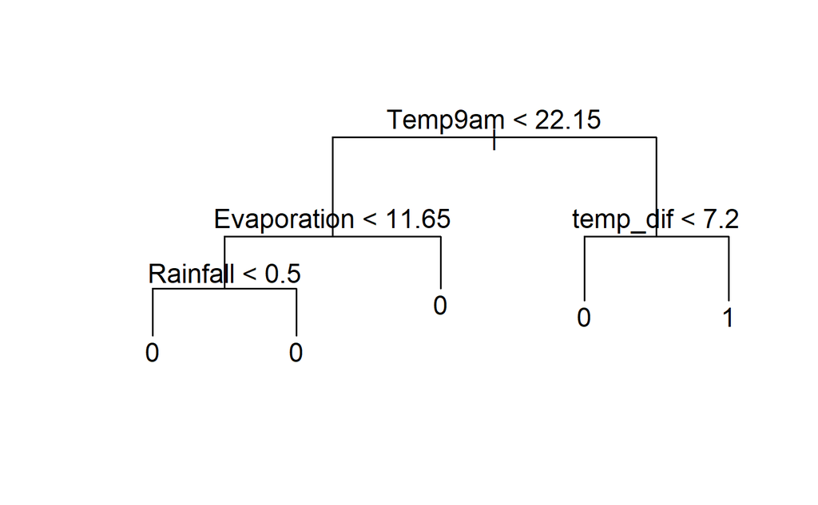

```r
plot(decision_tree_model)
text(decision_tree_model)
```

### Fitting a Naive Bayes Model

```r
naive_bayes_model <- naiveBayes(MHT~., data=WAUS_train)
pred_naive_bayes <- predict(naive_bayes_model, WAUS_test)
naive_bayes_cm <- table(actual=WAUS_test$MHT, predicted=pred_naive_bayes)

cms <- c(cms, list(naive_bayes_cm))
print(naive_bayes_cm)
```

```
      predicted
actual   0   1
     0 237  27
     1 187  49
```

### Fitting a Bagging model

```r
bagging_model <- bagging(MHT~., data=WAUS_train)
pred_bagging <- predict.bagging(bagging_model, WAUS_test)
bagging_cm <- table(actual=WAUS_test$MHT, predicted=apply(pred_bagging$prob, 1, which.max) - 1)
cms <- c(cms, list(bagging_cm))
print(bagging_cm)
```

```
      predicted
actual   0   1
     0 187  77
     1 135 101
```

### Fitting a Boosting model

```r
boosting_model <- boosting(MHT~., data=WAUS_train)
pred_boosting <- predict.boosting(boosting_model, WAUS_test)
boosting_cm <- table(actual=WAUS_test$MHT, predicted=apply(pred_boosting$prob, 1, which.max) - 1)

cms <- c(cms, list(boosting_cm))
print(boosting_cm)
```

```
      predicted
actual   0   1
     0 160 104
     1 113 123
```

### Fitting a Random Forest model

```r
rf_model <- randomForest(MHT~.,data=WAUS_train)
pred_rf <- predict(rf_model, WAUS_test)
rf_cm <- table(actual=WAUS_test$MHT, predicted=pred_rf)
cms <- c(cms, list(rf_cm))
print(rf_cm)
```

```
      predicted
actual   0   1
     0 156 108
     1  87 149
```